# EFI: COVID-19 Argentina

Garay Santiago, Ivan Escobar, Villavicencio Jonatan, Ibarra Matias

2025-11-09

# 1 Introducción

Este R Markdown contiene el pipeline completo para un proyecto de predicción de **nuevos casos diarios de COVID-19** en **Argentina**, usando el dataset completo de Our World in Data (`owid-covid-data.csv`).

Objetivo: predecir `new_cases` a 14 días con fundamento y medición de la confiabilidad del modelo. Se busca modelar casos diarios, entender correlaciones y construir un modelo de predicción.

# 2 Carga y filtrado de datos

En este paso se carga la base de datos completa de COVID-19.  
Luego filtramos únicamente para el país seleccionado (“Argentina”) y construimos un dataset con las variables de interés.

```
## _______________________________________________________________
```

# 3 Exploración inicial y gráficos

En esta sección analizamos cómo evolucionaron los casos diarios y los tests en el país seleccionado. Podemos observar tendencias, estacionalidades y posibles anomalías en los datos.

```
## _______________________________________________________________
```

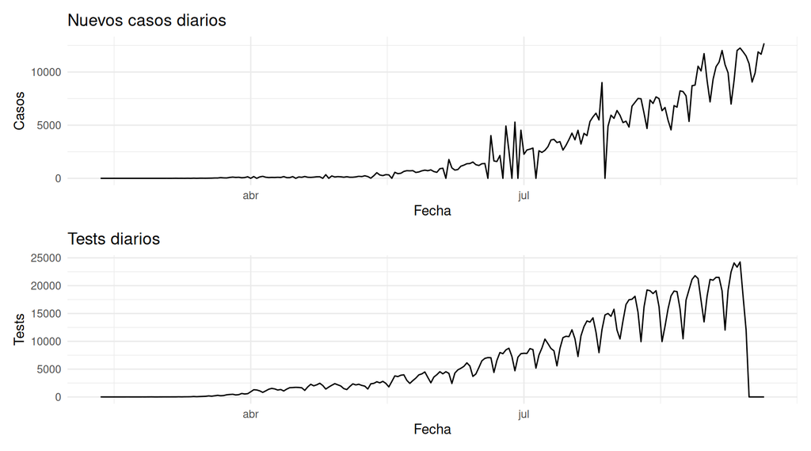

# 4 Distribución

```
## _______________________________________________________________
```

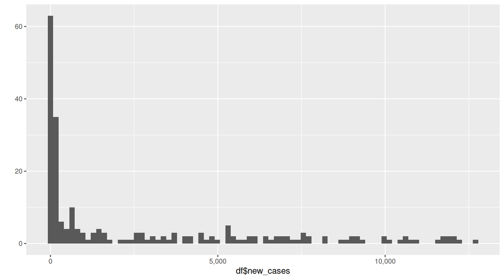